# TSWomen

### 1.2.7 Сравнение трендов

Сравним тренды, полученные посредством некоторых вышеупомянутых методов. На графике изображены тренд - скользящее среднее с длиной окна 12+1, тренд-полиномиальная регрессия порядка 26, тренд-локальная линейная регрессия (робастный вариант, span=0.05) и тренд-HP-filter при $\lambda=3000$:

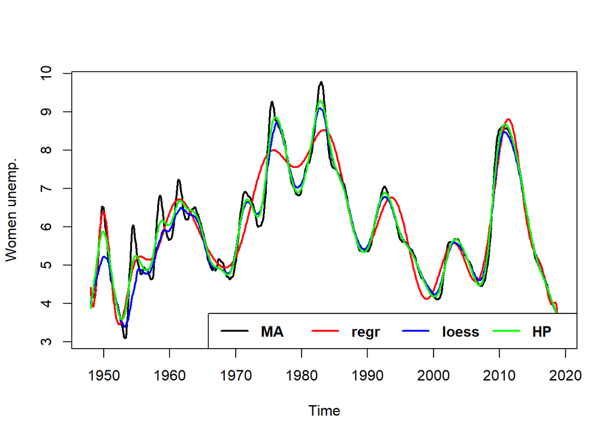

```r
plot.ts(cbind(ts.f13,  trModel26$fitted.values, loess.Model.05.iter$fitted, hp.Women3000$trend), plot.type = 'single', col = c('black', 'red','blue','green'),lwd=c(2,2,2,2), ylab = "Women unemp.")
legend("bottomright",paste(c("MA","regr","loess","HP")), col = c('black', 'red','blue','green'),lty=1,lw=c(2,2,2,2),text.font = 2,horiz=TRUE)
```

Скользящее среднее наиболее “отвечает” всем движениям ряда, полиномиальная регрессия описывает ряд грубее остальных, результаты, полученные при помощи локальной регрессии и HP-фильтра похожи, но HP-фильтр при этом более гладкий (хоть мы и брали совсем маленькую $\lambda$, относительно рекомендованного).

Справедливости ради заметим, что если брать скользящее среднее все-таки с большей длиной окна (24+1), то на аналогичном графике будет 3 похожих тренда:

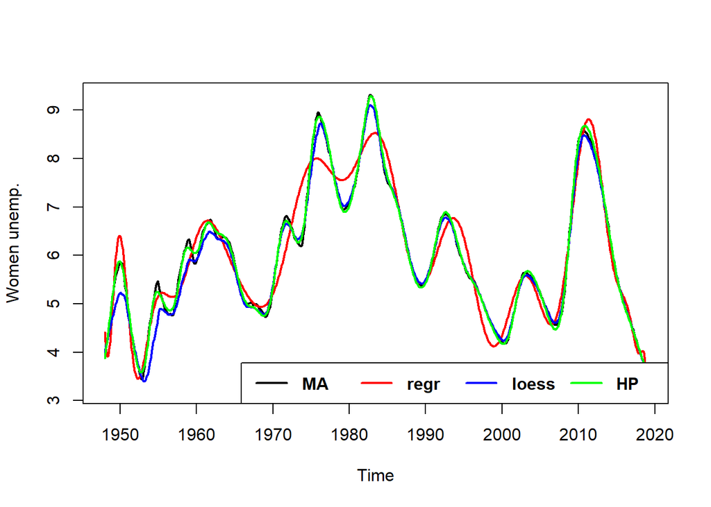

```r
plot.ts(cbind(ts.f25,  trModel26$fitted.values, loess.Model.05.iter$fitted, hp.Women3000$trend), plot.type = 'single', col = c('black', 'red','blue','green'),lwd=c(2,2,2,2), ylab = "Women unemp.")
legend("bottomright",paste(c("MA","regr","loess","HP")), col = c('black', 'red','blue','green'),lty=1,lw=c(2,2,2,2),text.font = 2,horiz=TRUE)
```

Таким образом, если цель дальнейшей работы с рядом позволяет проигнорировать небольшую часть тренда, то я бы предпочла использовать тренд, выделенный HP-фильтром при $\lambda=3000$ (в силу его схожести с результатом локальной регрессии, но более высокой гладкости). Однако если необходимо приблизить ряд максмально точно или выполнить тщательный de-trending, то наиболее подходящим вариантом кажется скользящее среднее с периодом 12+1 (оно выглядит лучше, чем результат локальной регрессии с сосвем маленьким span, который рассматривался в разделе 1.2.4).

# 2 Учебные примеры

## 2.1 Фильтр-ачх

###Сумма соседних точек

Ачх:

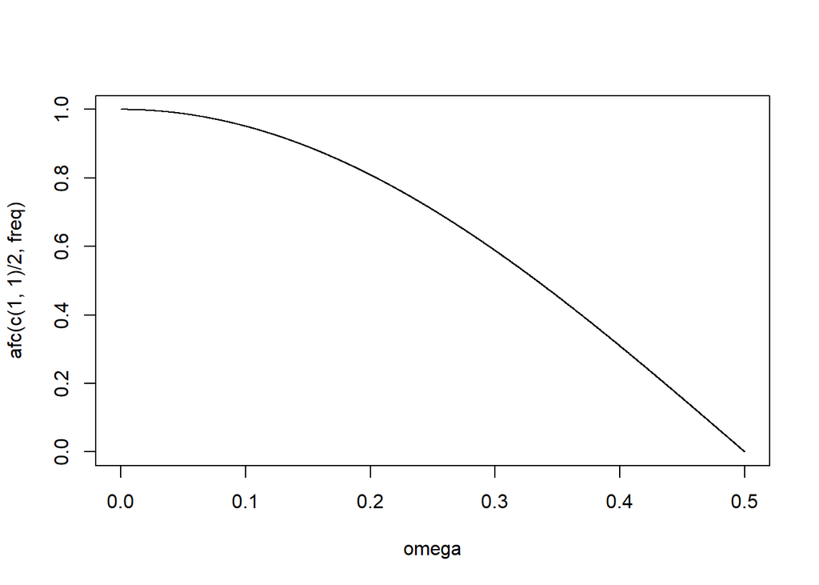

```r
plot(afc(c(1,1)/2, freq) ~ omega, type = "l")
```

Фильтр-сумма соседних точек = скользящее среднее с окном=2. Сглаживание (довольно слабое). Уменьшает вклад высоких частот (шума).

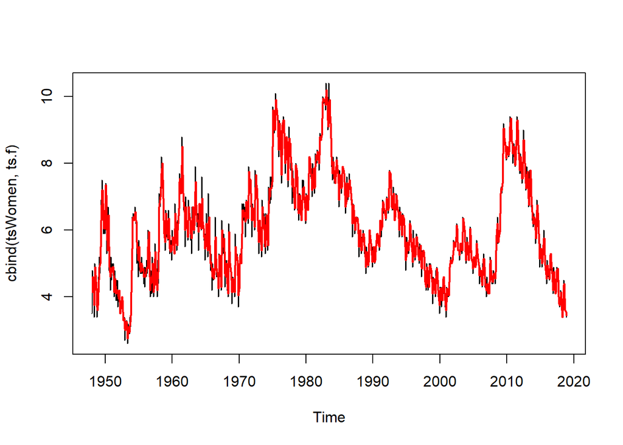

```r
ts.f<-stats::filter(tsWomen, filter = c(1,1)/2, sides = 1)
plot.ts(cbind(tsWomen, ts.f), plot.type = 'single', col = c('black', 'red'),lwd=c(1,2))
```

### 2.1.1 Разность соседних точек

АЧХ:

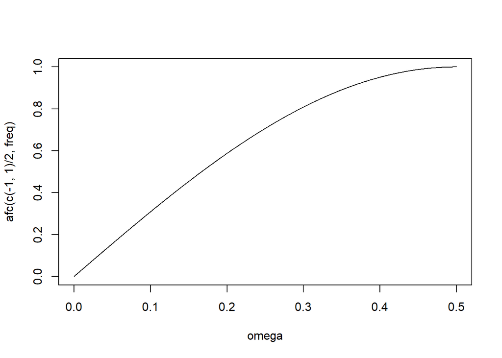

```r
plot(afc(c(-1,1)/2, freq) ~ omega, type = "l")
```

De-trending. Для нашего ряда:

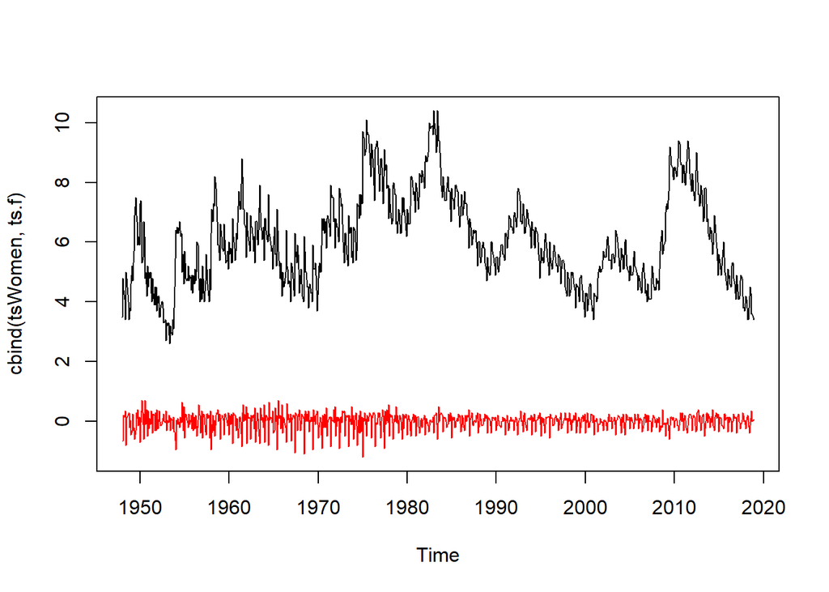

```r
ts.f<-stats::filter(tsWomen, filter = c(-1,1)/2, sides = 1)
plot.ts(cbind(tsWomen, ts.f), plot.type = 'single', col = c('black', 'red'),lwd=c(1,1))
```

Недостаток такого фильтра в том, что он усиливает высокие частоты и если наш ряд – это детерминированный тренд + шум, то какую-то часть тренда фильтр уберет, а шум при этом увеличит. (Например, если бы тренд был линейный, то фильтр убрал бы его полностью, а шум бы при этом усилился.)

## 2.2 Красный и белый шум

Красный шум:

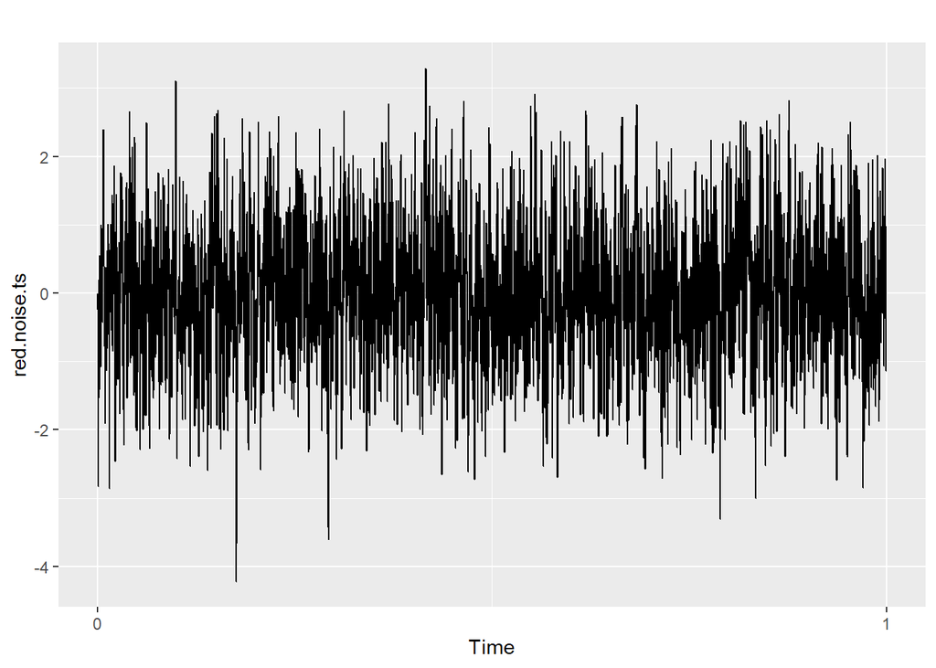

```r
red.noise<-colored_noise(5000, 0, 1, phi=0.6)
red.noise.ts<-ts(red.noise, frequency = 5000, start = 0)
autoplot(red.noise.ts)
```

Для того, чтобы оценить спектральную плотность, сгладим периодограмму при помощи скользящего среднего:

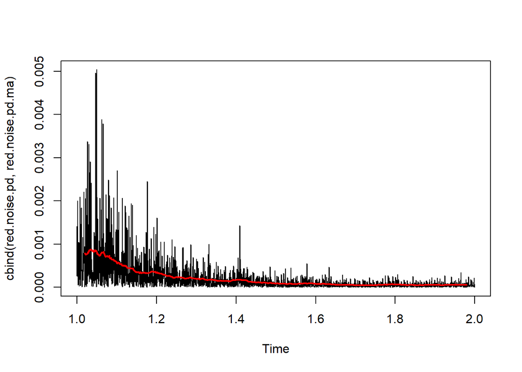

```r
t<-spec.pgram(red.noise.ts,log="no",plot=FALSE)
red.noise.pd<-ts(t$spec,frequency = 2500,start = 1)
red.noise.pd.ma<-ma(red.noise.pd, order = 100)
plot.ts(cbind(red.noise.pd, red.noise.pd.ma), plot.type = 'single', col = c('black', 'red'),lwd=c(1,2))
```

Белый шум:

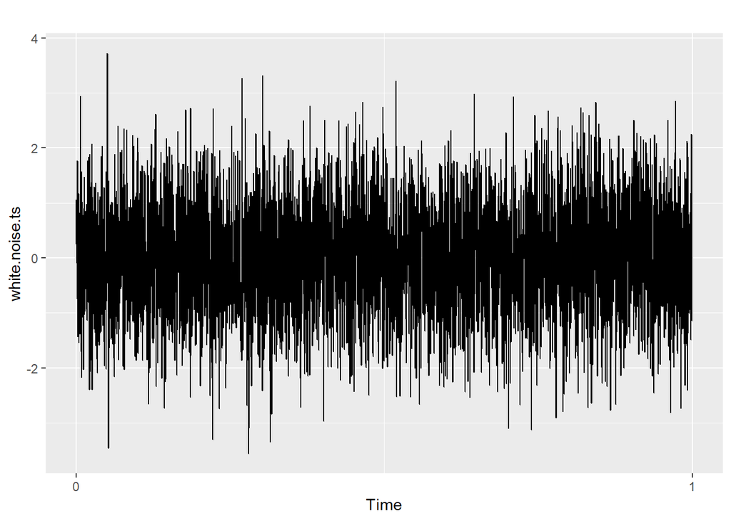

```r
white.noise<-colored_noise(5000, 0, 1, phi=0)
white.noise.ts<-ts(white.noise, frequency = 5000, start = 0)
autoplot(white.noise.ts)
```

Сглаживание периодограммы белого шума.

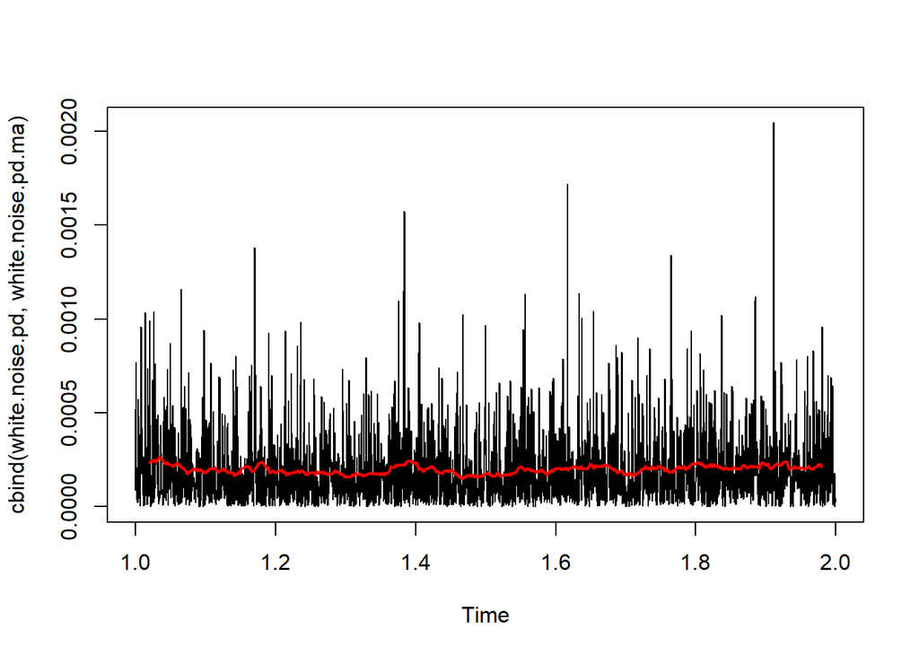

```r
t<-spec.pgram(white.noise.ts,log="no",plot = FALSE)
white.noise.pd<-ts(t$spec,frequency = 2500,start = 1)
white.noise.pd.ma<-ma(white.noise.pd, order = 100)
plot.ts(cbind(white.noise.pd, white.noise.pd.ma), plot.type = 'single', col = c('black', 'red'),lwd=c(1,2))
```